# Price Optimization Part 1: Methods for Price Elasticities for Consumer Products companies

Revology Analytics

5/4/2022

# 1 Load key packages and useful functions

We’ll get started by loading some key libraries and writing baseline functions that we’ll be using throughout our analysis. You can expand or collapse the **source code** for each section by clicking on the blue tabs.

```r
options(width = 1000)
knitr::opts_chunk$set(echo = TRUE, cache= TRUE, tidy = TRUE)

library(lazyeval)
library(knitr)
library(vip)
library(gt)
library(data.table)
library(corrplot)
library(ggthemes)
library(ggrepel)
library(ggpubr)
library(readxl)
library(skimr)
library(prophet)
library(forecast)
library(anytime)
library(doParallel)
library(scales)
library(gridExtra)
library(plotly)
library(timeDate)
library(tidyverse)
library(tidymodels)
library(DataExplorer)


# 1. Baseline functions ---------------------------------------------------

header_changes = function(mydata){
  setnames(mydata, names(mydata), tolower(names(mydata)))
  setnames(mydata, names(mydata), gsub(" ","_", names(mydata), fixed = TRUE))
  setnames(mydata, names(mydata), gsub("_(sum)","", names(mydata), fixed = TRUE))
  setnames(mydata, names(mydata), gsub("_(agg)","", names(mydata), fixed = TRUE))
  setnames(mydata, names(mydata), gsub("_(avg)","_avg", names(mydata), fixed = TRUE))
  setnames(mydata, names(mydata), gsub("(c)","", names(mydata), fixed = TRUE))
  setnames(mydata, names(mydata), gsub("$","dollar_volume", names(mydata), fixed = TRUE))
  setnames(mydata, names(mydata), gsub("%","pct", names(mydata), fixed = TRUE))
  setnames(mydata, names(mydata), gsub("w/o","without", names(mydata), fixed = TRUE))
  setnames(mydata, names(mydata), gsub("-","_", names(mydata), fixed = TRUE))
  setnames(mydata, names(mydata), gsub("&","", names(mydata), fixed = TRUE))
  setnames(mydata, names(mydata), gsub("/","_", names(mydata), fixed = TRUE))
  setnames(mydata, names(mydata), gsub("\\(","", names(mydata), fixed = TRUE))
  setnames(mydata, names(mydata), gsub("\\)","", names(mydata), fixed = TRUE))
  setnames(mydata, names(mydata), gsub(".","", names(mydata), fixed = TRUE))
  setnames(mydata, names(mydata), iconv(names(mydata), "UTF-8","ASCII", sub=""))
}


`%ni%` = Negate('%in%')


#function to round any number to the desired decimal interval (i.e. 4.28 to 4.50)
round_to_decimal <- function(x,decimal){
  y=x/decimal
  z=round(y)
  z*decimal
}

#quantile calculations
quantile_25 = function(x){quantile(x, 0.25)}
quantile_75 = function(x){quantile(x, 0.75)}
quantile_90 = function(x){quantile(x, 0.90)}


### Function to calculate rmse ################
rmse_calc = function(df){

  sqrt(mean((df$.fitted - df$units)^2))

}


### Function to calculate rmse with log-log regression ################

rmse_log = function(df){

  sqrt(mean((exp(df$.fitted) - exp(df$`log(units + 1)`))^2))

}



round_2 = function(x) (round(x, 2))


### Function for messy string cleaning ################
clean_text <- function(x) {
  x %>%
    str_remove_all("^RT:? ") %>%
    str_remove_all(" ?(f|ht)(tp)(s?)(://)(.*)[.|/](.*)") %>%
    str_replace_all("&amp;", "and") %>%
    str_remove_all("[[:punct:]]") %>%
    str_remove_all("@[[:alnum:]]+") %>%
    str_remove_all("#[[:alnum:]]+") %>%
    str_replace_all("\\\n", " ") %>%
    str_to_lower() %>%
    str_trim("both") %>%
    str_replace_all("brt", " ")
}


### Function to adjust elasticity estimates to 0 if the model outputs a positive number  ################
elast_adjust = function(x){
  if_else(x > 0 ,0,x)
}


### Function to obtain variable importance plots ################
varimp_plots = function(model){
  vip(model, scale = TRUE, num_features =25)
}


### Function to obtain variable importance scores ################
varimp_scores = function(model){
  vi(model, scale = TRUE, ice = T)
}
```

# 2 Data prepping for analysis and modeling

```r
data = readRDS('C:/Users/armin/OneDrive/Documents/GitHub/margin_analytics/cpg_retail_data_example_A.rds')
data$date <- as.Date(data$date)
data$promo_price <- NULL
```

## 2.1 Create key pricing and margin metrics

```r
data = data %>% mutate(
  year  = lubridate::year(date),
  avg_selling_price = sales_dollars / units,
  gp_per_unit = avg_selling_price - cost_per_unit,
  gp_pct = gp_per_unit / avg_selling_price,
  gp_dollars = sales_dollars * gp_pct,
  pct_units_sold_on_promo = promo_units / units,
  pct_units_feature = (feature_units) / units,
  pct_units_display = (display_units) / units
) %>%
  mutate_at(vars(contains('price')), round_2) %>% na.omit() %>%
  group_by(retailer, product, year) %>%
  mutate(
    price_ratio_vs_med = avg_selling_price / median(avg_selling_price, na.rm = T),
    price_ratio_vs_mean = avg_selling_price /
      mean(avg_selling_price, na.rm = T)
  ) %>% ungroup()



#keep only those products that have at least 104 weeks of sales history
#focus on the ones with the biggest price variation
retailer_filtering = data %>% group_by(retailer, product) %>% summarise(
  price_var = sd(avg_selling_price) / mean(avg_selling_price),
  units  = sum(units),
  num_weeks = n(),
  pct_units_feature = sum(feature_units, na.rm = T) / sum(units, na.rm = T),
  pct_units_display = sum(display_units, na.rm = T) / sum(units, na.rm = T)
) %>% ungroup() %>%
  filter(num_weeks >= 104) %>% group_by(retailer) %>%
  summarise(
    price_var = mean(price_var),
    num_weeks = mean(num_weeks),
    num_products = n_distinct(product),
    pct_units_feature = mean(pct_units_feature),
    pct_units_display = mean(pct_units_display)
  ) %>% ungroup()


target_retailer = 'Pubyern'

data = data %>% filter(retailer ==  target_retailer)

focus_product_list =  unique(data$product)
```

## 2.2 Create holiday variables

```r
superbowl = tibble(holiday = 'superbowl', date = as.Date(c('2014-02-02', '2015-02-01', '2016-02-07')))

#Custom data frame of US holidays
holidays = listHolidays("US")
currentYear <- getRmetricsOptions("currentYear")
holiday_years = tibble(year = currentYear:(currentYear - 10))

holiday_df = tibble(holiday = holidays)  %>% crossing(holiday_years) %>%
  rowwise() %>%
  mutate(date = lazy_eval(paste0(
    "as.Date(timeDate::", holiday, "(", year, "))"
  ))) %>% rowwise() %>%
  select(-year) %>% bind_rows(superbowl)


holiday_df_before = holiday_df %>% mutate(date = date - 1)
holiday_df_after = holiday_df %>% mutate(date = date + 1)
holiday_df = holiday_df %>% bind_rows(holiday_df_after) %>% bind_rows(holiday_df_before) %>% arrange(holiday, date)


#Create dummy variables
holiday_matrix = holiday_df %>% mutate(count = 1) %>% spread(holiday, count)



data = data %>% left_join(holiday_matrix) %>% replace(is.na(.), 0)
```

## 2.3 Create dummy variable for promotion

```r
#data %>% group_by(product) %>% skim(pct_units_display, pct_units_feature)

#Determine what constitutes a promotion or a feature and display
feature_or_display_unit_threshold = 1 / 3  #at least 33% of the stores/units have to be on feature or on display support


data = data %>% mutate(
  feature_or_display_promo  = if_else(
    pct_units_feature >= feature_or_display_unit_threshold |
      pct_units_display >= feature_or_display_unit_threshold,
    1,
    0
  )
)
```

## 2.4 Quick glimpse of our data

```{=html}

| date | retailer | category | size | brand | units | sales_dollars | promo_units | display_units | feature_units | promo_sales_dollars | display_only_pct_of_stores | feature_only_pct_of_stores | feature_and_display_pct_of_stores | product | cost_per_unit | year | avg_selling_price | gp_per_unit | gp_pct | gp_dollars | pct_units_sold_on_promo | pct_units_feature | pct_units_display | price_ratio_vs_med | price_ratio_vs_mean | superbowl | USChristmasDay | USColumbusDay | USCPulaskisBirthday | … |
| --- | --- | --- | --- | --- | --- | --- | --- | --- | --- | --- | --- | --- | --- | --- | --- | --- | --- | --- | --- | --- | --- | --- | --- | --- | --- | --- | --- | --- | --- | --- |
| 2016-11-19 | Pubyern | ice pops | 10 count | Chocolat baby | 8997.6 | 47117.50 | 74.0508 | 0 | 0 | 354.4218 | 0 | 0 | 0 | Chocolat baby 10 count ice pops | 4.44510 | 2016 | 5.24 | 0.7915744 | 0.1511598 | 7122.270 | 0.008230061 | 0 | 0 | 1.0000000 | 1.0745201 | 0 | 0 | 0 | 0 | … |
| 2016-11-19 | Pubyern | ice pops | 16 count | Vanilla diva | 5456.4 | 31299.03 | 1882.1556 | 0 | 0 | 8050.8060 | 0 | 0 | 0 | Vanilla diva 16 count ice pops | 4.29792 | 2016 | 5.74 | 1.4382852 | 0.2507381 | 7847.859 | 0.344944579 | 0 | 0 | 0.8790199 | 0.9162167 | 0 | 0 | 0 | 0 | … |
| 2016-11-19 | Pubyern | ice pops | 18 count | Vanilla diva | 33321.6 | 206061.73 | 8318.6712 | 0 | 0 | 40447.4274 | 0 | 0 | 0 | Vanilla diva 18 count ice pops | 4.23984 | 2016 | 6.18 | 1.9441887 | 0.3143887 | 64783.479 | 0.249648012 | 0 | 0 | 0.9435115 | 0.9842432 | 0 | 0 | 0 | 0 | … |

```

## 2.5 Create variables for seasonality

```r
#Understand seasonality at the category level (ice pops)
#use forecast package to extract fourier terms https://rdrr.io/cran/forecast/man/fourier.html
#msts data: https://robjhyndman.com/hyndsight/seasonal-periods/
#loop through various orders for fourier terms and the RMSE for the best one


data_prophet_cat = data %>% group_by(date) %>% summarise(units = sum(units, na.rm = T)) %>% ungroup() %>%
  select(date, units) %>% rename(ds = date, y = units)

min_date = as.Date(min(data_prophet_cat$ds))
num_periods = length(unique(data_prophet_cat$ds))

train = 0.7 #training data portion
train_periods = ceiling(train * num_periods)

validation_periods = num_periods - train_periods # number of weeks used in validation data


data_p_train = data_prophet_cat %>% filter(ds <= (min_date + ((train_periods -
                                                                 1) * 7)))
data_p_validation = data_prophet_cat %>% anti_join(data_p_train, by = 'ds')


library(doParallel)
registerDoParallel(cores = detectCores() - 2)

fourier_term_ranking = foreach(
  i = 3:20,
  .combine = rbind,
  .packages = c('prophet', 'forecast', 'tidyverse')
) %dopar% {
  ts_m <- prophet(data_p_train,  yearly.seasonality = T)
  ts_m <-
    prophet(weekly.seasonality = F)
  ts_m <-
    add_seasonality(ts_m,
                    name = 'yearly',
                    fourier.order = i,
                    period = 365.25)
  ts_m = fit.prophet(ts_m, data_p_train)

  ts_m_future <-
    make_future_dataframe(ts_m, periods = validation_periods, freq = 'week')

  forecast <-
    predict(ts_m, ts_m_future)
  forecast$ds <- as.Date(forecast$ds)

  data_p_validation_small = data_p_validation %>% inner_join(select(forecast, ds, yhat))

  rmse = sqrt(mean((data_p_validation_small$y - data_p_validation_small$yhat) ^2))
  fourier_terms_s = tibble(K = i, rmse = rmse)

  fourier_terms_s
}


fourier_term_optimal = fourier_term_ranking$K[which.min(fourier_term_ranking$rmse)]

data_ts = data_prophet_cat %>% arrange(ds)

data_ts = ts(data_ts$y,
             freq = 365.25 / 7,
             start = lubridate::decimal_date(lubridate::ymd(min(data_ts$ds))))

data_msts = msts(data_ts, seasonal.periods =  365.25 / 7)

fourier_series = fourier(data_msts, K = fourier_term_optimal) %>%
  data.frame()  #fourier series to be used in our models


#create fourier series data set for later use

fourier_series_df = data_prophet_cat %>% rename(date = ds) %>% select(-y) %>%
  arrange(date) %>%
  bind_cols(fourier_series) %>%
  nest(fourier_values = matches('.52'))
```

Back to Table of Contents

# 3 Visualize unit sales and profitability trends

## 3.1 View key cost, pricing and margin stats by product

```r
price_summary_by_prod = data %>% select(product, cost_per_unit, avg_selling_price, gp_per_unit, gp_pct) %>%
  pivot_longer(-product, names_to = 'metrics', values_to = 'values') %>%
  group_by(product, metrics) %>%
  summarise_all(
    list(
      min = min,
      quantile_25 = quantile_25,
      median = median,
      quantile_75 = quantile_75,
      max = max
    )
  ) %>%
  pivot_longer(-c(product, metrics),
               names_to = 'stats',
               values_to = 'values') %>%
  pivot_wider(names_from = 'metrics', values_from = 'values')


#View list of most important variables by product
price_summary_by_prod %>%
  gt(rowname_col = 'stats', groupname_col = 'product') %>% cols_align(align = 'center') %>%
  tab_spanner(label = "Key Pricing and Profitability Metrics",
                columns = c('avg_selling_price','cost_per_unit', 'gp_per_unit', 'gp_pct')) %>%
  fmt_currency(
    columns = vars(avg_selling_price, cost_per_unit, gp_per_unit),
    currency = "USD"
  ) %>%
  fmt_percent(
    columns = vars(gp_pct),
    decimals = 0
  ) %>%
  cols_label(
    avg_selling_price = 'Avg. Selling Price',
    cost_per_unit = 'Cost/Unit',
    gp_pct  = "Gross Profit Pct",
    gp_per_unit = "GP$/Unit"
  ) %>%
  tab_header(
    title = md("*Summary Stats**")
  )
```

*Summary Stats**

|  | Key Pricing and Profitability Metrics Avg. Selling Price | Key Pricing and Profitability Metrics Cost/Unit | Key Pricing and Profitability Metrics GP$/Unit | Key Pricing and Profitability Metrics Gross Profit Pct |
| --- | --- | --- | --- | --- |
| Chocolat baby 10 count ice pops |  |  |  |  |
| min | $3.75 | $4.04 | −$0.70 | −19% |
| quantile_25 | $4.38 | $4.24 | $0.04 | 1% |
| median | $4.48 | $4.24 | $0.24 | 5% |
| quantile_75 | $5.23 | $4.45 | $0.79 | 15% |
| max | $5.25 | $4.45 | $0.80 | 15% |
| Vanilla diva 16 count ice pops |  |  |  |  |
| min | $4.30 | $3.91 | −$0.00 | −0% |
| quantile_25 | $6.51 | $4.10 | $2.21 | 34% |
| median | $6.67 | $4.10 | $2.48 | 37% |
| quantile_75 | $6.70 | $4.30 | $2.60 | 39% |
| max | $6.74 | $4.30 | $2.79 | 42% |
| Vanilla diva 18 count ice pops |  |  |  |  |
| min | $3.28 | $3.85 | −$0.96 | −29% |
| quantile_25 | $6.54 | $4.05 | $2.29 | 35% |
| median | $6.67 | $4.05 | $2.54 | 38% |
| quantile_75 | $6.72 | $4.24 | $2.68 | 40% |
| max | $6.75 | $4.24 | $2.86 | 43% |

Back to Table of Contents

## 3.2 Average Selling Price (ASP), Profitability, Units and Seasonality trends

```r
# Explore ASP, Units and seasonality trends =====

price_units_visual = function(prod_filter){

          data_filtered = data %>% filter(product == prod_filter) %>%
            group_by(product, date) %>% summarise(units = sum(units, na.rm = T)) %>%
            ungroup() %>% arrange(date)

          data_prophet = data_filtered %>%
            select(date, units) %>% rename(ds = date, y = units)


          min_date = as.Date(min(data_prophet$ds))
          num_periods = length(unique(data_prophet$ds))

          train = 0.7 #training data portion
          train_periods = ceiling(train * num_periods)

          validation_periods = num_periods -train_periods # number of weeks used in validation data


          data_p_train = data_prophet %>% filter(ds <= (min_date + ((train_periods-1)*7)))
          data_p_validation = data_prophet %>% anti_join(data_p_train, by = 'ds')

          fourier_term_optimal = fourier_series_df %>%
            sample_n(1) %>% unnest(cols = c('fourier_values'))

          fourier_term_optimal = (dim(fourier_term_optimal)[2]-2)/2

          ts_m <- prophet(data_p_train,  yearly.seasonality = T)
          ts_m <- prophet(weekly.seasonality = F)
          ts_m <- add_seasonality(ts_m, name = 'yearly', fourier.order = fourier_term_optimal, period = 365.25)
          ts_m = fit.prophet(ts_m, data_p_train)

          ts_m_future <- make_future_dataframe(ts_m, periods = validation_periods, freq = 'week')

          forecast <- predict(ts_m, ts_m_future)


          ### Plot the seasonality ################
          pe_good_plot_seasonality = prophet_plot_components(ts_m, forecast, render_plot = F)[[2]]    #seasonality plot


          pe_good_plot_seasonality = pe_good_plot_seasonality +
            scale_y_continuous(name= 'Units', labels = scales::comma_format()) +
            ggtitle("Annual seasonality") +
            theme(axis.title.y = element_text(color = 'grey23', size=14),
                  axis.title.x = element_text(color = 'grey23', size=14),
                  axis.text.x = element_text(size = 10),
                  axis.text.y = element_text(size = 14),
                  plot.title = element_text(vjust=1,
                                            colour="black",
                                            size = 14,
                                            face="bold"),
                  legend.title = element_blank(), legend.position = "none")



          ### Plot price vs. units relationship ################
          data_filtered =   data %>% filter(product == prod_filter)


          pe_good_plot_cor  <- ggplot(data_filtered, aes(avg_selling_price, units)) +
            geom_point(aes(color = "black"), shape = 21, fill = "white", size = 3, stroke = 1.5) +
            scale_x_continuous(name = 'Price', labels = scales::dollar_format(decimal = ".")) +
            scale_y_continuous(name= 'Units', labels = scales::comma_format()) +
            geom_smooth(method = 'loess', se = T, color = "darkgrey") +
            theme_fivethirtyeight() +
            ggtitle("Price vs. Units response") +
            scale_color_economist() +
            theme(axis.title.y = element_text(color = 'grey23', size=14),
                  axis.title.x = element_text(color = 'grey23', size=14),
                  axis.text = element_text(size = 14),
                  plot.title = element_text(vjust=1,
                                            colour="black",
                                            size = 14,
                                            face="bold"),
                  legend.title = element_blank(), legend.position = "none")



          ### Plot gross profit by month ################

          data_filtered =   data %>% filter(product == prod_filter) %>%
            mutate(year_month = lubridate::floor_date(date, 'month')) %>%
            group_by(year_month) %>%
            summarise(gp_dollars = sum(gp_dollars, na.rm= T),
                      units = sum(units, na.rm = T)) %>% ungroup()


          pe_good_plot_gp  <- ggplot(data_filtered, aes(as.Date(year_month), gp_dollars)) +
            geom_col(aes(color = "black"),  fill = "red") +
            scale_x_date(name = 'Date') +
            scale_y_continuous(name = 'Gross Profit $', labels = scales::dollar_format(),
                   limits = c(min(data_filtered$gp_dollars-1), max(data_filtered$gp_dollars+1)),
                   oob = rescale_none) +
            theme_economist() +
            ggtitle('Monthly Gross Profit $') +
            scale_color_economist() +
            theme(axis.title.y = element_text(color = 'grey23', size=14),
                  axis.title.x = element_text(color = 'grey23', size=14),
                  axis.text = element_text(size = 14),
                  plot.title = element_text(vjust=1,
                                            colour="red",
                                            size = 14,
                                            face="bold"),
                  legend.title = element_blank(), legend.position = "none")



          pe_good_plot_units <- ggplot(data_filtered, aes(as.Date(year_month), units)) +
            geom_col(aes(color = "black"),  fill = "blue") +
            scale_x_date(name = 'Date') +
            scale_y_continuous(name = 'Units', labels = scales::comma_format(),
                               limits = c(min(data_filtered$units-1), max(data_filtered$units+1)),
                               oob = rescale_none) +
            theme_economist() +
            ggtitle('Monthly Unit Sales') +
            scale_color_economist() +
            theme(axis.title.y = element_text(color = 'grey23', size=14),
                  axis.title.x = element_text(color = 'grey23', size=14),
                  axis.text = element_text(size = 14),
                  plot.title = element_text(vjust=1,
                                            colour="blue",
                                            size = 14,
                                            face="bold"),
                  legend.title = element_blank(), legend.position = "none")


          figure1 <- ggarrange(pe_good_plot_units, pe_good_plot_seasonality,
                               pe_good_plot_gp, pe_good_plot_cor,
                               ncol = 2, nrow = 2)

          figure1 <-  annotate_figure(figure1,
                      #top = text_grob(paste(prod_filter), color = "red", face = "bold", size = 14),
                      bottom = text_grob("revology.ai", color = "darkgrey",
                                         hjust = 1, x = 1, face = "bold", size = 11),
                      top = text_grob("", color = "darkgrey",
                                      hjust = 1, x = 1, face = "bold", size = 18),
                      fig.lab = paste0(prod_filter), fig.lab.face = 'bold', fig.lab.size = 18)

          print(figure1)   }
```

### 3.2.1 Product level analysis

#### 3.2.1.1 Chocolat baby 10 count ice pops

Key pricing and profitability trends

[figure not shown]

#### 3.2.1.2 Vanilla diva 16 count ice pops

Key pricing and profitability trends

[figure not shown]

#### 3.2.1.3 Vanilla diva 18 count ice pops

Key pricing and profitability trends

[figure not shown]

Back to Table of Contents

# 4 Understand variable importance

## 4.1 Which predictors are the most important?

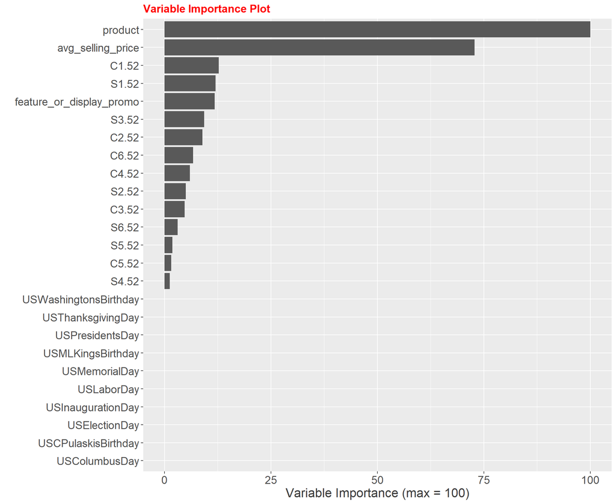

```r
# Create initial data set for variable importance =====

by_product_data_reg = data %>%
              select(product, date, units, avg_selling_price, feature_or_display_promo, superbowl:USWashingtonsBirthday) %>%
                       inner_join(fourier_series_df) %>% unnest(cols = 'fourier_values') %>%
                              select(-date)

by_product_data_reg$product <- factor(by_product_data_reg$product)


# Variable importance =====

### Run basic Random Forest model ################
rf_basic <- rand_forest(mode = "regression", mtry = floor(sqrt(.preds())), trees = 1000) %>%
    set_engine("ranger", importance = 'permutation') %>%
    fit(
      units  ~ . ,
      data = by_product_data_reg)




### Variable importance plots ################


varimp_score =  varimp_scores(rf_basic)

varimp_ggplot <- varimp_plots(rf_basic) +
      scale_y_continuous(name= 'Variable Importance (max = 100)', labels = scales::comma_format()) +
      ggtitle("Variable Importance Plot") +
      theme(axis.title.y = element_text(color = 'grey23', size=12),
            axis.title.x = element_text(color = 'grey23', size=16),
            axis.text = element_text(size = 14),
            plot.title = element_text(vjust=1,
                                      colour="red",
                                      size = 14,
                                      face="bold"),
            legend.title = element_blank(), legend.position = "none")


varimp_ggplot
```

## 4.2 Create final data set for linear regressions

```r
by_product_data_reg_final = tibble()

for(i in seq_along(focus_product_list)){
  data_filtered  = data %>% filter(product == focus_product_list[i]) %>%
    select(product, date, units, avg_selling_price, feature_or_display_promo)

  data_filtered = data_filtered %>% inner_join(fourier_series_df) %>%
    unnest(cols = 'fourier_values') %>%
    select(-date) %>% group_by(product) %>% nest()

  by_product_data_reg_final = data_filtered %>% bind_rows(by_product_data_reg_final)

}

by_product_data_reg_final
```

| product | data |
| --- | --- |
| Vanilla diva 18 count ice pops |  |
| Vanilla diva 16 count ice pops |  |
| Chocolat baby 10 count ice pops |  |

Let’s see how the regression data set looks like for **Vanilla diva 18 count ice pops**:

```r
by_product_data_reg_final %>% filter(product == 'Vanilla diva 18 count ice pops') %>%
  unnest(cols = c('data')) %>% ungroup() %>% select(-product) %>% head() %>% mutate_at(vars(matches('.52')), round_2) %>%
        gt() %>% cols_align(align = 'center') %>%
        tab_spanner(label = "Fourier terms",
            columns = c('S1.52' ,'C1.52','S2.52' ,'C2.52','S3.52' ,
                        'C3.52' ,'S4.52' ,'C4.52','S5.52', 'C5.52', 'S6.52' ,'C6.52')) %>%
            tab_header(
              title = md("**Data used for price elasticity modeling**"),
              subtitle = md("Vanilla diva 18 count ice pops; first 6 of 104 observations"))
```

**Data used for price elasticity modeling**

Vanilla diva 18 count ice pops; first 6 of 104 observations

| units | avg_selling_price | feature_or_display_promo | Fourier terms S1.52 | Fourier terms C1.52 | Fourier terms S2.52 | Fourier terms C2.52 | Fourier terms S3.52 | Fourier terms C3.52 | Fourier terms S4.52 | Fourier terms C4.52 | Fourier terms S5.52 | Fourier terms C5.52 | Fourier terms S6.52 | Fourier terms C6.52 |
| --- | --- | --- | --- | --- | --- | --- | --- | --- | --- | --- | --- | --- | --- | --- |
| 33321.6 | 6.18 | 0 | 0.00 | 1.00 | 0.00 | 1.00 | 0.00 | 1.00 | 0.00 | 1.00 | 0.00 | 1.00 | 0.00 | 1.00 |
| 33361.2 | 6.21 | 0 | -0.12 | 0.99 | -0.24 | 0.97 | -0.35 | 0.94 | -0.46 | 0.89 | -0.57 | 0.82 | -0.66 | 0.75 |
| 33423.6 | 5.94 | 0 | -0.24 | 0.97 | -0.46 | 0.89 | -0.66 | 0.75 | -0.82 | 0.57 | -0.94 | 0.35 | -0.99 | 0.12 |
| 217903.2 | 3.28 | 0 | -0.35 | 0.94 | -0.66 | 0.75 | -0.89 | 0.46 | -0.99 | 0.12 | -0.97 | -0.24 | -0.82 | -0.57 |
| 47370.0 | 6.47 | 1 | -0.46 | 0.89 | -0.82 | 0.57 | -0.99 | 0.12 | -0.94 | -0.35 | -0.66 | -0.75 | -0.24 | -0.97 |
| 41852.4 | 6.48 | 1 | -0.57 | 0.82 | -0.94 | 0.35 | -0.97 | -0.24 | -0.66 | -0.75 | -0.12 | -0.99 | 0.46 | -0.89 |

Back to Table of Contents

# 5 The “Good” approach for estimating own Price Elasticity (aka. “mid-point method”)

## 5.1 About the mid-point method

## 5.2 Understand the need for interaction between promotional events and prices

```r
feature_display_promo_stats = by_product_data_reg_final %>% unnest(cols = c('data')) %>%
            group_by(product, feature_or_display_promo) %>%
                        summarise(avg_selling_price = round(mean(avg_selling_price, na.rm = T),2),
                                  avg_units = round(mean(units, na.rm = T),0),
                                  num_weeks = n()) %>% ungroup() %>%
                pivot_wider(names_from = feature_or_display_promo, values_from = c(avg_selling_price, avg_units, num_weeks)) %>%
                      mutate(promo_units_ratio = round(avg_units_1/avg_units_0,1),
                             pct_weeks_on_promotion = num_weeks_1/num_weeks_0)  %>%
                       rename(regular_price = avg_selling_price_0,
                              promo_price = avg_selling_price_1,
                              regular_weekly_units = avg_units_0,
                              promo_weekly_units = avg_units_1) %>% select(-num_weeks_1, -num_weeks_0)

feature_display_promo_stats %>%
  gt() %>% cols_align(align = 'center')  %>%
  fmt_currency(
    columns = vars(regular_price, promo_price),
    currency = "USD"
  ) %>%
  fmt_number(
    columns = vars(regular_weekly_units, promo_weekly_units),
    decimals = 0, sep_mark = ","
  ) %>%
    fmt_percent(
      columns = vars(promo_units_ratio, pct_weeks_on_promotion),
      decimals = 0
    ) %>%
  cols_label(
    regular_price = 'Regular Price',
    promo_price = 'Promo Price',
    regular_weekly_units = "Avg. Weekly Units (Regular Week, No Promotion)",
    promo_weekly_units = "Avg. Weekly Units (Promotion)",
    promo_units_ratio = "Promo vs. Non-Promo Week Unit Ratio",
    pct_weeks_on_promotion =  "Pct of Weeks with Promotions"
  ) %>%
  tab_header(
    title = md("**Avg. weekly prices and units during regular vs. feature/display promotional weeks**")) %>%
  tab_source_note(md("Promotional event is defined by `feature_or_display_promo` flag = 1"))
```

**Avg. weekly prices and units during regular vs. feature/display promotional weeks**

| product | Regular Price | Promo Price | Avg. Weekly Units (Regular Week, No Promotion) | Avg. Weekly Units (Promotion) | Promo vs. Non-Promo Week Unit Ratio | Pct of Weeks with Promotions |
| --- | --- | --- | --- | --- | --- | --- |
| Chocolat baby 10 count ice pops | $4.70 | $3.82 | 12,478 | 24,221 | 190% | 17% |
| Vanilla diva 16 count ice pops | $6.60 | $5.43 | 6,204 | 16,989 | 270% | 22% |
| Vanilla diva 18 count ice pops | $6.48 | $5.84 | 37,495 | 55,148 | 150% | 20% |

Promotional event is defined by `feature_or_display_promo` flag = 1

## 5.3 Build model

### 5.3.1 Include interaction term between feature/display promotion and price

```r
#includes interaction term between promo event and price
by_product_data_reg_final =  by_product_data_reg_final %>%
                  mutate(pe_good_model = purrr::map(data, ~lm(units ~ avg_selling_price*feature_or_display_promo +., data = .x)),
                         pe_good_model_coefs = purrr::map(pe_good_model, tidy),
                         pe_good_model_summary = purrr::map(pe_good_model, glance),
                         pe_good_model_details = purrr::map(pe_good_model, augment))

by_product_data_reg_final
```

| product | data | pe_good_model | pe_good_model_coefs | pe_good_model_summary | pe_good_model_details |
| --- | --- | --- | --- | --- | --- |
| Vanilla diva 18 count ice pops |  |  |  |  |  |
| Vanilla diva 16 count ice pops |  |  |  |  |  |
| Chocolat baby 10 count ice pops |  |  |  |  |  |

### 5.3.2 Model stats

```r
pe_good_model_summary = by_product_data_reg_final %>% unnest(pe_good_model_summary) %>%
                   select(-data, -pe_good_model, -pe_good_model_coefs)

pe_good_model_summary
```

| product | r.squared | adj.r.squared | sigma | statistic | p.value | df | logLik | AIC | BIC | deviance | df.residual | nobs | pe_good_model_details |
| --- | --- | --- | --- | --- | --- | --- | --- | --- | --- | --- | --- | --- | --- |
| Vanilla diva 18 count ice pops | 0.8499157 | 0.8243332 | 12379.334 | 33.22248 | 8.911030e-30 | 15 | -1118.9563 | 2271.913 | 2316.867 | 13485815787 | 88 | 104 |  |
| Vanilla diva 16 count ice pops | 0.6927692 | 0.6404003 | 4692.281 | 13.22864 | 1.201574e-16 | 15 | -1018.0649 | 2070.130 | 2115.084 | 1937540174 | 88 | 104 |  |
| Chocolat baby 10 count ice pops | 0.9262309 | 0.9136567 | 1742.142 | 73.66081 | 4.113571e-43 | 15 | -915.0214 | 1864.043 | 1908.997 | 267085253 | 88 | 104 |  |

```r
pe_good_model_coefs = by_product_data_reg_final %>% unnest(pe_good_model_coefs) %>%
                        select(-data, -pe_good_model, -pe_good_model_summary) %>%
                                filter(grepl('price|promo', term, ignore.case = T))

pe_good_model_coefs
```

| product | term | estimate | std.error | statistic | p.value | pe_good_model_details |
| --- | --- | --- | --- | --- | --- | --- |
| Vanilla diva 18 count ice pops | avg_selling_price | -34254.8276 | 2150.7236 | -15.927118 | 1.174461e-27 |  |
| Vanilla diva 18 count ice pops | feature_or_display_promo | -51735.9713 | 20972.4716 | -2.466851 | 1.556801e-02 |  |
| Vanilla diva 18 count ice pops | avg_selling_price:feature_or_display_promo | 7704.9812 | 3576.7633 | 2.154177 | 3.395928e-02 |  |
| Vanilla diva 16 count ice pops | avg_selling_price | 2694.5693 | 2591.1702 | 1.039904 | 3.012331e-01 |  |
| Vanilla diva 16 count ice pops | feature_or_display_promo | 72752.6326 | 17796.1557 | 4.088109 | 9.587378e-05 |  |
| Vanilla diva 16 count ice pops | avg_selling_price:feature_or_display_promo | -10814.3949 | 2754.0421 | -3.926736 | 1.707310e-04 |  |
| Chocolat baby 10 count ice pops | avg_selling_price | -728.1051 | 508.7835 | -1.431070 | 1.559518e-01 |  |
| Chocolat baby 10 count ice pops | feature_or_display_promo | 27666.2313 | 17191.2423 | 1.609321 | 1.111279e-01 |  |
| Chocolat baby 10 count ice pops | avg_selling_price:feature_or_display_promo | -5327.9709 | 4481.2281 | -1.188953 | 2.376565e-01 |  |

### 5.3.3 Adjust coefficients for interactions

```r
pe_good_model_coefs_2 = pe_good_model_coefs %>%
          select(product, term, estimate) %>%
                  pivot_wider(names_from = term, values_from = estimate) %>%
          rename(price_coef_regular = avg_selling_price) %>%
                mutate(price_coef_promotion = price_coef_regular+`avg_selling_price:feature_or_display_promo`)

pe_good_model_coefs_2
```

| product | price_coef_regular | feature_or_display_promo | avg_selling_price:feature_or_display_promo | price_coef_promotion |
| --- | --- | --- | --- | --- |
| Vanilla diva 18 count ice pops | -34254.8276 | -51735.97 | 7704.981 | -26549.846 |
| Vanilla diva 16 count ice pops | 2694.5693 | 72752.63 | -10814.395 | -8119.826 |
| Chocolat baby 10 count ice pops | -728.1051 | 27666.23 | -5327.971 | -6056.076 |

### 5.3.4 Estimate elasticities

```r
pe_good_estimate = pe_good_model_coefs_2 %>%
            select(price_coef_regular, price_coef_promotion) %>%
              inner_join(feature_display_promo_stats) %>% ungroup() %>%
                  mutate(price_elasticity_regular = (regular_price/regular_weekly_units)*price_coef_regular,
                         price_elasticity_promo = (promo_price/promo_weekly_units)*price_coef_promotion) %>%
                            select(product, price_elasticity_regular, price_elasticity_promo) %>%
                  mutate_at(.vars = c('price_elasticity_regular','price_elasticity_promo'), .funs = elast_adjust)

pe_good_estimate
```

| product | price_elasticity_regular | price_elasticity_promo |
| --- | --- | --- |
| Vanilla diva 18 count ice pops | -5.9200235 | -2.8115453 |
| Vanilla diva 16 count ice pops | 0.0000000 | -2.5952471 |
| Chocolat baby 10 count ice pops | -0.2742502 | -0.9551303 |

```r
by_product_data_reg_final <- by_product_data_reg_final %>%
                             mutate(pe_good_model_rmse = purrr::map(pe_good_model_details, rmse_calc))


by_product_data_reg_final %>% select(product, pe_good_model_rmse) %>% unnest(cols = c('pe_good_model_rmse'))
```

| product | pe_good_model_rmse |
| --- | --- |
| Vanilla diva 18 count ice pops | 11387.331 |
| Vanilla diva 16 count ice pops | 4316.271 |
| Chocolat baby 10 count ice pops | 1602.538 |

Back to Table of Contents

# 6 The “Better” approach for estimating own Price Elasticity (aka. “log-log method”)

## 6.1 About the log-log method

## 6.2 Build model

```r
#includes interaction term between promo event and price
by_product_data_reg_final =  by_product_data_reg_final %>%
  mutate(pe_better_model = purrr::map(data, ~lm(log(units+1) ~ . +
      log(avg_selling_price)*feature_or_display_promo - avg_selling_price, data = .x)),
         pe_better_model_coefs = purrr::map(pe_better_model, tidy),
         pe_better_model_summary = purrr::map(pe_better_model, glance),
         pe_better_model_details = purrr::map(pe_better_model, augment))

by_product_data_reg_final %>% select(-matches('pe_good_model'))
```

| product | data | pe_better_model | pe_better_model_coefs | pe_better_model_summary | pe_better_model_details |
| --- | --- | --- | --- | --- | --- |
| Vanilla diva 18 count ice pops |  |  |  |  |  |
| Vanilla diva 16 count ice pops |  |  |  |  |  |
| Chocolat baby 10 count ice pops |  |  |  |  |  |

### 6.2.1 Model stats

```r
pe_better_model_summary = by_product_data_reg_final %>% unnest(pe_better_model_summary) %>%
  select(-data, -pe_better_model, -pe_better_model_coefs)  %>% select(-matches('pe_good_model'))

pe_better_model_summary
```

| product | r.squared | adj.r.squared | sigma | statistic | p.value | df | logLik | AIC | BIC | deviance | df.residual | nobs | pe_better_model_details |
| --- | --- | --- | --- | --- | --- | --- | --- | --- | --- | --- | --- | --- | --- |
| Vanilla diva 18 count ice pops | 0.9471967 | 0.9381962 | 0.1046388 | 105.23760 | 1.934201e-49 | 15 | 95.870216 | -157.74043 | -112.7858 | 0.9635372 | 88 | 104 |  |
| Vanilla diva 16 count ice pops | 0.7869646 | 0.7506517 | 0.2814152 | 21.67179 | 2.703046e-23 | 15 | -7.018675 | 48.03735 | 92.9920 | 6.9691158 | 88 | 104 |  |
| Chocolat baby 10 count ice pops | 0.9339114 | 0.9226463 | 0.1025412 | 82.90301 | 3.436223e-45 | 15 | 97.976180 | -161.95236 | -116.9977 | 0.9252943 | 88 | 104 |  |

```r
pe_better_model_coefs = by_product_data_reg_final %>% unnest(pe_better_model_coefs) %>%
  select(-data, -pe_better_model, -pe_better_model_summary) %>%
  filter(grepl('price|promo', term, ignore.case = T)) %>%  select(-matches('pe_good_model'))

pe_better_model_coefs
```

| product | term | estimate | std.error | statistic | p.value | pe_better_model_details |
| --- | --- | --- | --- | --- | --- | --- |
| Vanilla diva 18 count ice pops | feature_or_display_promo | -0.8327332 | 0.26696481 | -3.1192622 | 2.451149e-03 |  |
| Vanilla diva 18 count ice pops | log(avg_selling_price) | -2.2082308 | 0.09133644 | -24.1768878 | 1.248386e-40 |  |
| Vanilla diva 18 count ice pops | feature_or_display_promo:log(avg_selling_price) | 0.5177274 | 0.15434759 | 3.3542951 | 1.175403e-03 |  |
| Vanilla diva 16 count ice pops | feature_or_display_promo | 6.1130746 | 1.87195278 | 3.2656137 | 1.557386e-03 |  |
| Vanilla diva 16 count ice pops | log(avg_selling_price) | 0.9199856 | 0.95963034 | 0.9586875 | 3.403428e-01 |  |
| Vanilla diva 16 count ice pops | feature_or_display_promo:log(avg_selling_price) | -3.1176391 | 1.00355041 | -3.1066093 | 2.547531e-03 |  |
| Chocolat baby 10 count ice pops | feature_or_display_promo | 1.8524669 | 1.37902955 | 1.3433120 | 1.826250e-01 |  |
| Chocolat baby 10 count ice pops | log(avg_selling_price) | -0.2345651 | 0.14200159 | -1.6518485 | 1.021295e-01 |  |
| Chocolat baby 10 count ice pops | feature_or_display_promo:log(avg_selling_price) | -1.0966833 | 1.02539699 | -1.0695207 | 2.877600e-01 |  |

### 6.2.2 Estimate elasticities

```r
pe_better_estimate = pe_better_model_coefs %>%
  select(product, term, estimate) %>%
  pivot_wider(names_from = term, values_from = estimate) %>%
  rename(price_elasticity_regular = `log(avg_selling_price)`) %>%
  mutate(price_elasticity_promo = price_elasticity_regular +
           `feature_or_display_promo:log(avg_selling_price)`) %>%
  select(product, price_elasticity_regular, price_elasticity_promo) %>%
  mutate_at(.vars = c('price_elasticity_regular','price_elasticity_promo'), .funs = elast_adjust)

pe_better_estimate
```

| product | price_elasticity_regular | price_elasticity_promo |
| --- | --- | --- |
| Vanilla diva 18 count ice pops | -2.2082308 | -1.690503 |
| Vanilla diva 16 count ice pops | 0.0000000 | -2.197653 |
| Chocolat baby 10 count ice pops | -0.2345651 | -1.331248 |

### 6.2.3 Model accuracy on training data

```r
by_product_data_reg_final <- by_product_data_reg_final %>%
  mutate(pe_better_model_rmse = purrr::map(pe_better_model_details, rmse_log))

by_product_data_reg_final %>% select(product, pe_good_model_rmse, pe_better_model_rmse) %>%
  unnest(cols = c('pe_good_model_rmse', 'pe_better_model_rmse'))
```

| product | pe_good_model_rmse | pe_better_model_rmse |
| --- | --- | --- |
| Vanilla diva 18 count ice pops | 11387.331 | 8510.195 |
| Vanilla diva 16 count ice pops | 4316.271 | 4303.184 |
| Chocolat baby 10 count ice pops | 1602.538 | 1598.192 |

Back to Table of Contents

## 6.3 Additional Resources

Introduction to Machine Learning with the Tidyverse: https://education.rstudio.com/blog/2020/02/conf20-intro-ml/ Gentle introduction to tidymodels: https://rviews.rstudio.com/2019/06/19/a-gentle-intro-to-tidymodels/ Prophet for ts forecasting and seasonal decomposition: https://facebook.github.io/prophet/docs/quick_start.html#r-api